# TP Pierre Médina et Soroush Soleymani

2026-11-06

## TP Analyse et fouille de données

TP Analyse et fouille de données Pierre Médina et Soroush Soleymani

## Question 1: Import et vérification des types

```r
library(FactoMineR)
library(factoextra)

communes <- read.csv("communes.csv", stringsAsFactors = TRUE, encoding = "UTF-8")

str(communes)
```

```
## 'data.frame':    200 obs. of  12 variables:
##  $ id_commune         : Factor w/ 200 levels "C001","C002",..: 1 2 3 4 5 6 7 8 9 10 ...
##  $ region             : Factor w/ 5 levels "Centre","Est",..: 3 5 2 4 4 5 1 3 5 4 ...
##  $ type_commune       : Factor w/ 3 levels "Periurbaine",..: 2 2 3 2 2 2 3 3 2 2 ...
##  $ transport_principal: Factor w/ 4 levels "Deux_roues_motorise",..: 4 4 2 4 4 4 2 2 4 1 ...
##  $ densite            : num  5 24 693 21 15 ...
##  $ revenu_median      : num  16720 17350 20670 22170 22010 ...
##  $ taux_chomage       : num  7.9 8.5 11.2 5.8 7.6 11.4 7.7 11.6 9.4 4.4 ...
##  $ part_diplomes_sup  : num  5 5 36.7 17.7 15.3 5 37.7 26.6 9.4 14.9 ...
##  $ prix_m2            : num  700 700 3150 2030 780 700 4160 3490 1340 1410 ...
##  $ part_plus65        : num  24.7 30 21.2 18.6 25 27.6 12 22.3 28.4 29.9 ...
##  $ temps_trajet       : num  30 28 21 37 32 32 23 29 25 37 ...
##  $ equipements        : num  0.5 0.5 9.6 2.6 1.4 0.5 12 8.7 1.7 1.3 ...
```

```r
summary(communes)
```

```
##    id_commune     region        type_commune          transport_principal
##  C001   :  1   Centre:28   Periurbaine:74    Deux_roues_motorise: 21
##  C002   :  1   Est   :39   Rurale     :72    Transports_commun  : 41
##  C003   :  1   Nord  :32   Urbaine    :54    Velo_marche        : 26
##  C004   :  1   Ouest :49                     Voiture            :112
##  C005   :  1   Sud   :52
##  C006   :  1
##  (Other):194
##     densite        revenu_median    taux_chomage    part_diplomes_sup
##  Min.   :   2.00   Min.   :12850   Min.   : 2.500   Min.   : 5.00
##  1st Qu.:  37.75   1st Qu.:19960   1st Qu.: 6.975   1st Qu.:16.65
##  Median : 166.00   Median :21480   Median : 8.300   Median :23.30
##  Mean   : 554.09   Mean   :21470   Mean   : 8.296   Mean   :23.49
##  3rd Qu.: 495.25   3rd Qu.:23315   3rd Qu.: 9.800   3rd Qu.:29.80
##  Max.   :7444.00   Max.   :27190   Max.   :15.400   Max.   :47.20
##                    NA's   :5
##     prix_m2      part_plus65     temps_trajet    equipements
##  Min.   : 700   Min.   :10.60   Min.   :14.00   Min.   : 0.500
##  1st Qu.:1528   1st Qu.:19.00   1st Qu.:26.00   1st Qu.: 2.700
##  Median :2155   Median :23.20   Median :30.00   Median : 5.850
##  Mean   :2319   Mean   :22.65   Mean   :29.34   Mean   : 5.779
##  3rd Qu.:3132   3rd Qu.:26.40   3rd Qu.:33.00   3rd Qu.: 8.700
##  Max.   :5560   Max.   :35.20   Max.   :46.00   Max.   :17.500
##                                 NA's   :3
```

Dans notre jeu de données les variables reéion, type_commune et transport_principal sont des variables qualitatives. Pour les analyser dans R, nous devons donc les déclarer comme des facteurs.

## Question 2: Valeurs manquantes & Nettoyage des données

```r
library(dplyr)

lignesAvecNA = communes %>% filter(if_any(everything(), is.na))
```

Comme il n’y a que 8 lignes sur 200 communes, il est possible de supprimer ses lignes sans que cela n’ai de trop grande incidence (car en dessous de 5%). On créer donc un nouveau jeu de data sans ces lignes, c’est de lui dont nous nous serviront par la suite. On conserve donc 192 communes.

```r
donneesSansNA = communes %>% filter(!if_any(everything(), is.na))
```

## Question 3: Statistiques descriptives et transformation de la densité

```r
mesMoyennes = c()
mesMaxs = c()
mesMins = c()
mesEcartTyp = c()



for (colonne in names(donneesSansNA)) {
  if (is.numeric(donneesSansNA[[colonne]])) {
        mesMoyennes[colonne] = mean(donneesSansNA[[colonne]], na.rm = TRUE)
        mesEcartTyp[colonne] = sd(donneesSansNA[[colonne]], na.rm = TRUE)
        mesMins[colonne]= min(donneesSansNA[[colonne]], na.rm = TRUE)
        mesMaxs[colonne] = max(donneesSansNA[[colonne]], na.rm = TRUE)}
}

print(mesMoyennes)
```

```
##           densite     revenu_median      taux_chomage part_diplomes_sup
##        567.505208      21479.322917          8.285937         23.606771
##           prix_m2       part_plus65      temps_trajet       equipements
##       2330.416667         22.627083         29.322917          5.817708
```

```r
print(mesMaxs)
```

```
##           densite     revenu_median      taux_chomage part_diplomes_sup
##            7444.0           27190.0              15.4              47.2
##           prix_m2       part_plus65      temps_trajet       equipements
##            5560.0              35.2              46.0              17.5
```

```r
print(mesMins)
```

```
##           densite     revenu_median      taux_chomage part_diplomes_sup
##               2.0           12850.0               2.5               5.0
##           prix_m2       part_plus65      temps_trajet       equipements
##             700.0              10.6              14.0               0.5
```

```r
print(mesEcartTyp)
```

```
##           densite     revenu_median      taux_chomage part_diplomes_sup
##       1139.800809       2734.643187          2.303619          9.484841
##           prix_m2       part_plus65      temps_trajet       equipements
##       1088.106494          5.164417          5.605709          3.639141
```

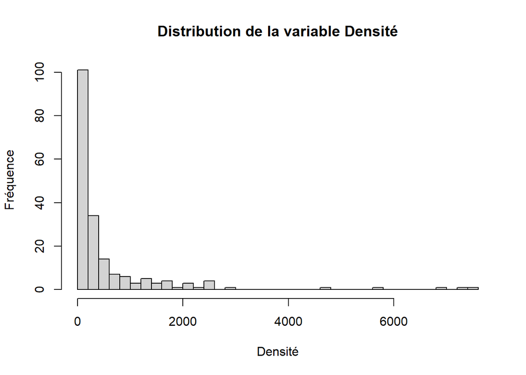

```r
donneesSansNA$LogDensite <- log(donneesSansNA$densite)

hist(donneesSansNA$densite,
     main = "Distribution de la variable Densité",
     xlab = "Densité",
     ylab = "Fréquence",
     breaks = 50)
```

On observe qu’il y a beaucoup plus de communes à faible densité que de communes à grandes densités. La densité est très asymétrique : la moyenne est loin de la médiane et l’écart-type dépasse la moyenne. Une poignée de communes très denses étire la queue de la distribution vers la droite.

Comme l’ACP repose sur les corrélations linéaires et sur la variance : quelques valeurs extrêmes suffiraient à tirer le premier axe à elles seules. Le logarithme resserre les grandes valeurs et rend la distribution à peu près symétrique. Dans la suite, on travaille avec LogDensite.

## Question 4: Matrice des corrélations

```r
library(corrplot)

vars <- c("LogDensite", "revenu_median", "taux_chomage", "part_diplomes_sup",
          "prix_m2", "part_plus65", "temps_trajet", "equipements")

cor_mat <- cor(donneesSansNA[, vars])
round(cor_mat, 2)
```

```
##                   LogDensite revenu_median taux_chomage part_diplomes_sup
## LogDensite              1.00          0.16         0.38              0.58
## revenu_median           0.16          1.00        -0.68              0.74
## taux_chomage            0.38         -0.68         1.00             -0.31
## part_diplomes_sup       0.58          0.74        -0.31              1.00
## prix_m2                 0.76          0.64        -0.15              0.86
## part_plus65            -0.53         -0.13        -0.20             -0.39
## temps_trajet           -0.45         -0.02        -0.16             -0.24
## equipements             0.84          0.47         0.07              0.75
##                   prix_m2 part_plus65 temps_trajet equipements
## LogDensite           0.76       -0.53        -0.45        0.84
## revenu_median        0.64       -0.13        -0.02        0.47
## taux_chomage        -0.15       -0.20        -0.16        0.07
## part_diplomes_sup    0.86       -0.39        -0.24        0.75
## prix_m2              1.00       -0.39        -0.34        0.86
## part_plus65         -0.39        1.00         0.26       -0.49
## temps_trajet        -0.34        0.26         1.00       -0.37
## equipements          0.86       -0.49        -0.37        1.00
```

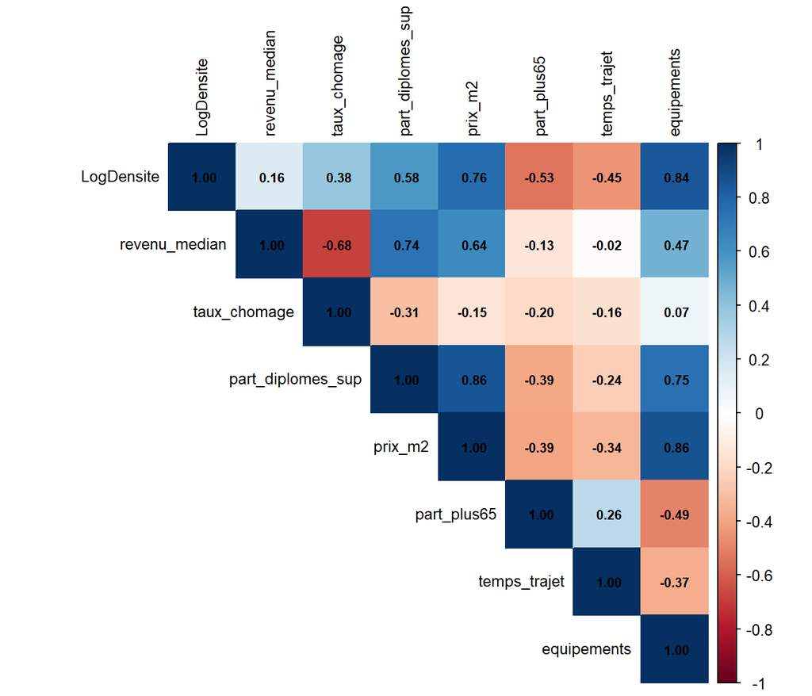

```r
corrplot(cor_mat, method = "color", type = "upper",
         addCoef.col = "black", number.cex = 0.7, tl.cex = 0.8, tl.col = "black")
```

```r
paires <- which(upper.tri(cor_mat), arr.ind = TRUE)
df_cor <- data.frame(var1 = rownames(cor_mat)[paires[, 1]],
                     var2 = colnames(cor_mat)[paires[, 2]],
                     r = round(cor_mat[paires], 2))
head(df_cor[order(-abs(df_cor$r)), ], 3)
```

```
##                 var1        var2    r
## 10 part_diplomes_sup     prix_m2 0.86
## 26           prix_m2 equipements 0.86
## 22        LogDensite equipements 0.84
```

## Question 5: Tableau de contingence et profils-lignes

Nous allons croiser les variables qualitatives `type_commune` et `transport_principal` pour observer leur répartition conjointe, puis calculer les profils-lignes en pourcentage pour analyser la part de chaque mode de transport au sein de chaque type de commune.

```r
tab_contingence <- table(donneesSansNA$type_commune, donneesSansNA$transport_principal)


print(tab_contingence)
```

```
##
##               Deux_roues_motorise Transports_commun Velo_marche Voiture
##   Periurbaine                  11                12           3      45
##   Rurale                        6                 2           8      52
##   Urbaine                       3                26          14      10
```

```r
profils_lignes <- prop.table(tab_contingence, margin = 1) * 100

print(round(profils_lignes, 2))
```

```
##
##               Deux_roues_motorise Transports_commun Velo_marche Voiture
##   Periurbaine               15.49             16.90        4.23   63.38
##   Rurale                     8.82              2.94       11.76   76.47
##   Urbaine                    5.66             49.06       26.42   18.87
```

On observe que la Voiture est beaucoup plus présente en zone périurbaine et rurales à la différence des zones urbaines, à l’inverse les transports en communs sont bien plus utilisés en zones urbaines. Ce sont des conclusions qui paraissent cohérentes avec la réalité, ce qui assure le bon déroulement de nos étapes de calculs du tableau de contingences.

## Question 6: Faut-il centrer-réduire ?

Il est indispensable de centrer et réduire les variables avant l’ACP car elles possèdent des unités hétérogènes et des écarts-types extrêmement disparates. Sans cette standardisation, les variables présentant de grands ordres de grandeur, telles que le revenu médian, écraseraient artificiellement la variance des indicateurs plus petits comme les équipements.

La fonction PCA() du package FactoMineR effectue heureusement cette transformation de manière automatique.

## Question 7: ACP normée avec FactoMineR

```r
donnees_pca <- donneesSansNA[, c(
  "revenu_median", "taux_chomage", "part_diplomes_sup", "prix_m2",
  "part_plus65", "temps_trajet", "equipements", "LogDensite",

  "region", "type_commune", "transport_principal",
    "densite"
)]

res.pca <- PCA(donnees_pca,
               scale.unit = TRUE,
               ncp = 8,
               quali.sup = 9:11,
               quanti.sup = 12,
               graph = FALSE)

print(res.pca$eig)
```

```
##        eigenvalue percentage of variance cumulative percentage of variance
## comp 1 4.14070836             51.7588545                          51.75885
## comp 2 1.99745689             24.9682112                          76.72707
## comp 3 0.76222898              9.5278623                          86.25493
## comp 4 0.61817918              7.7272398                          93.98217
## comp 5 0.16982362              2.1227953                          96.10496
## comp 6 0.13981635              1.7477044                          97.85267
## comp 7 0.10481127              1.3101408                          99.16281
## comp 8 0.06697534              0.8371918                         100.00000
```

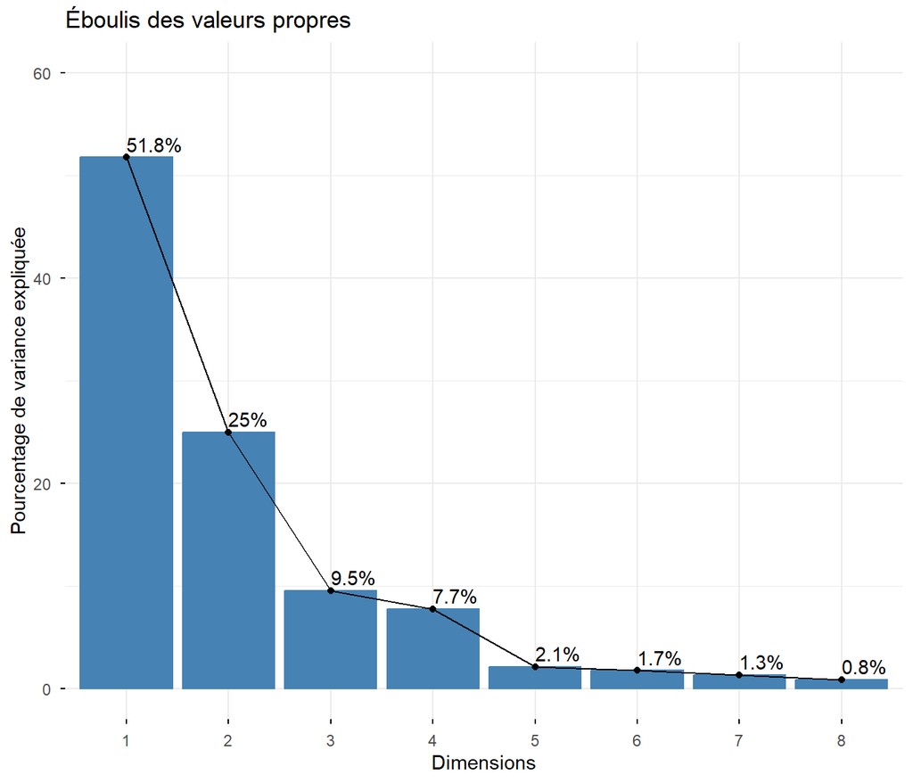

```r
fviz_eig(res.pca,
         addlabels = TRUE,
         ylim = c(0, 60),
         main = "Éboulis des valeurs propres",
         ylab = "Pourcentage de variance expliquée",
         xlab = "Dimensions")
```

## Question 8: Nombre d’axes retenus

1. Critère de Kaiser : La règle de Kaiser consiste à conserver les axes dont la valeur propre est supérieure à 1. En lisant le tableau fourni, seuls les deux premiers axes remplissent cette condition.
2. Critère du coude : L’observation du graphique de l’éboulis montre une chute importante du pourcentage de variance expliquée entre la première et la deuxième dimension, suivie d’un net point d’inflexion (le “coude”) au niveau de la dimension 3 (qui ne représente plus que 9.5 % de la variance). Cela indique qu’il faut conserver les deux premières dimensions.
3. Part d’inertie cumulée : Le tableau des valeurs propres indique qu’en retenant uniquement les composantes 1 et 2, on parvient à expliquer 76.72 % de la variance totale du jeu de données.

Conclusion : La convergence de ces trois critères nous amène à retenir 2 axes principaux. Cette sélection est optimale : elle nous permet de réduire la complexité du jeu de données de 8 variables initiales à seulement 2 dimensions, tout en conservant plus des trois quarts (environ 76.7 %) de l’information de départ.

## Question 9: Cercle des corrélations et nommage des axes

```r
library(factoextra)


coord_var <- res.pca$var$coord[, 1:2]


cos2_var <- res.pca$var$cos2[, 1:2]
contrib_var <- res.pca$var$contrib[, 1:2]

indicateurs_var <- data.frame(
  Coord_Dim1 = coord_var[, 1], Contrib_Dim1 = contrib_var[, 1], Cos2_Dim1 = cos2_var[, 1],
  Coord_Dim2 = coord_var[, 2], Contrib_Dim2 = contrib_var[, 2], Cos2_Dim2 = cos2_var[, 2]
)
print(round(indicateurs_var, 3))
```

```
##                   Coord_Dim1 Contrib_Dim1 Cos2_Dim1 Coord_Dim2 Contrib_Dim2
## revenu_median          0.628        9.514     0.394      0.721       26.040
## taux_chomage          -0.089        0.193     0.008     -0.926       42.915
## part_diplomes_sup      0.890       19.134     0.792      0.295        4.364
## prix_m2                0.947       21.659     0.897      0.099        0.493
## part_plus65           -0.569        7.815     0.324      0.358        6.424
## temps_trajet          -0.442        4.727     0.196      0.390        7.616
## equipements            0.925       20.673     0.856     -0.138        0.948
## LogDensite             0.821       16.285     0.674     -0.473       11.200
##                   Cos2_Dim2
## revenu_median         0.520
## taux_chomage          0.857
## part_diplomes_sup     0.087
## prix_m2               0.010
## part_plus65           0.128
## temps_trajet          0.152
## equipements           0.019
## LogDensite            0.224
```

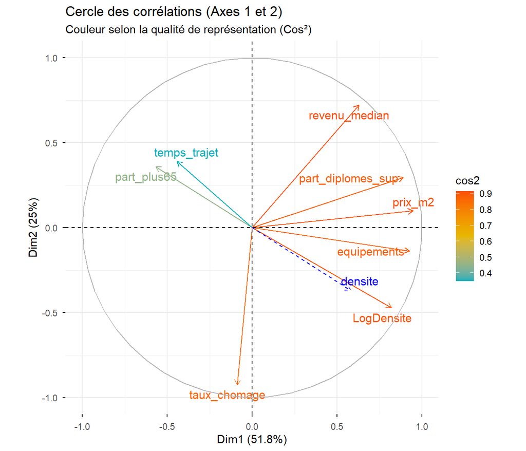

```r
fviz_pca_var(res.pca, axes = c(1, 2),
             col.var = "cos2",
             gradient.cols = c("#00AFBB", "#E7B800", "#FC4E07"),
             repel = TRUE) +
  labs(title = "Cercle des corrélations (Axes 1 et 2)",
       subtitle = "Couleur selon la qualité de représentation (Cos²)")
```

Analyse du cercle des corrélations Les variables situées à la périphérie du cercle sont très bien représentées sur ces deux premiers axes. L’Axe 1 est fortement structuré par les variables d’équipements, du prix au m², de la part des diplômés et du LogDensite, qui contribuent toutes massivement et dans le même sens.

On peut donc définir Axe 1 = attractivité urbaine , Axe 2 = fragilité socio-démographique

De plus, la projection cohérente de la variable illustrative (densité brute) dans la même direction que le LogDensite valide méthodologiquement la transformation logarithmique effectuée lors de la préparation des données.

## Question 10: Variable mal représentée sur le plan (1, 2)

```r
cos2_plan <- rowSums(res.pca$var$cos2[, 1:2])
sort(round(cos2_plan, 2))
```

```
##      temps_trajet       part_plus65      taux_chomage       equipements
##              0.35              0.45              0.87              0.87
## part_diplomes_sup        LogDensite     revenu_median           prix_m2
##              0.88              0.90              0.91              0.91
```

```r
round(res.pca$var$cos2["temps_trajet", 1:3], 2)
```

```
## Dim.1 Dim.2 Dim.3
##  0.20  0.15  0.60
```

la variable temps_trajet est effectivement la plus mal représentée sur le plan (1, 2) car sa flèche est la plus proche du centre et sa couleur indique le cos^2 le plus faible. N’étant pas correctement expliquée par ces deux premières dimensions, elle se projette nécessairement mieux sur un axe de rang supérieur (très probablement l’Axe 3)

## Question 11: Nuage des individus et ellipses

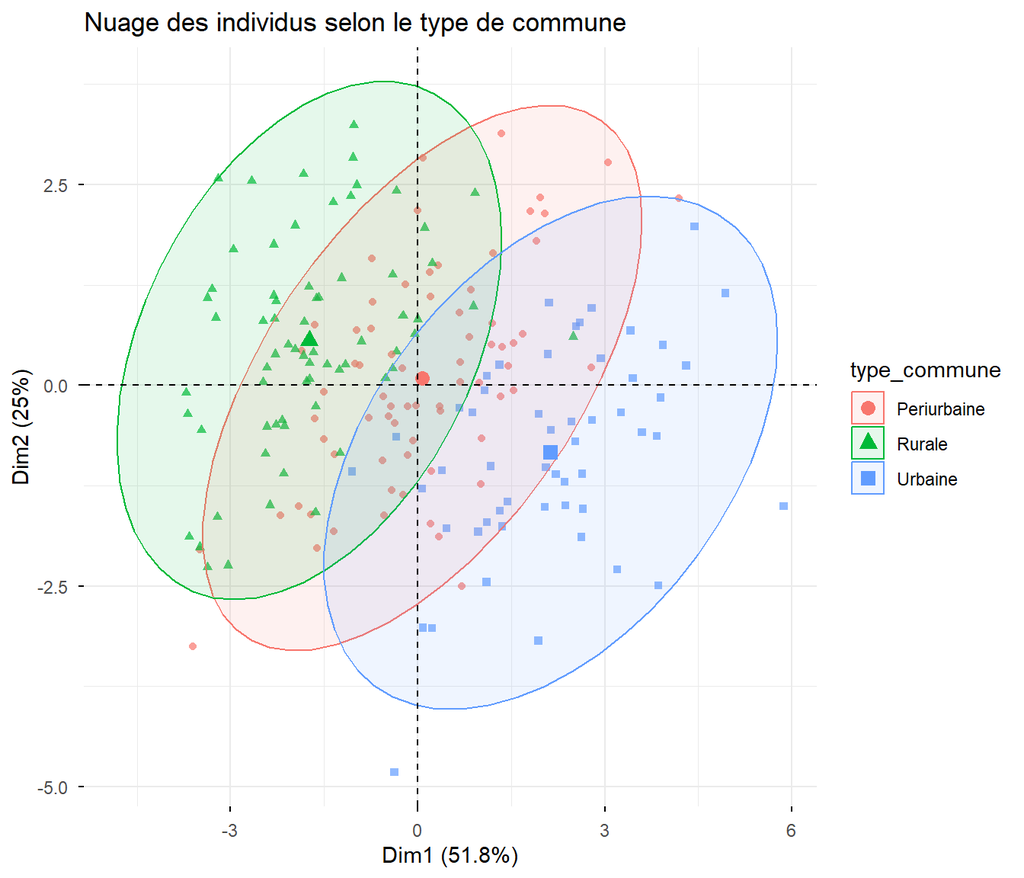

```r
fviz_pca_ind(res.pca,
             habillage = "type_commune",
             addEllipses = TRUE,
             ellipse.level = 0.95,
             geom = "point",
             alpha.ind = 0.7) +
  labs(title = "Nuage des individus selon le type de commune")
```

```r
print(round(res.pca$quali.sup$v.test, 2))
```

```
##                     Dim.1 Dim.2 Dim.3 Dim.4 Dim.5 Dim.6 Dim.7 Dim.8
## Centre               0.20  0.63 -0.97  0.23 -0.62  0.28 -2.02 -0.31
## Est                  1.56 -0.88  1.24 -1.91  0.42  1.51 -0.77  2.86
## Nord                -0.54 -3.11 -0.52 -1.72  0.39  1.00 -0.38  0.36
## Ouest               -1.10  1.63  1.98 -2.08  0.34 -0.81  0.73  1.37
## Sud                 -0.05  1.32 -1.88  5.09 -0.55 -1.66  1.95 -4.05
## Periurbaine          0.39  0.69  6.83  4.06 -0.01 -1.30 -0.50  1.47
## Rurale              -8.74  4.05 -3.97 -4.26  1.43  1.29 -0.50 -1.36
## Urbaine              8.93 -5.07 -3.13  0.17 -1.52  0.02  1.08 -0.13
## Deux_roues_motorise -1.01  0.31  0.62  0.79 -0.12  0.49  0.76 -1.25
## Transports_commun    5.02 -2.59 -0.43  1.23 -1.09  0.44  0.10 -1.06
## Velo_marche          1.24 -1.56 -0.29 -1.40 -0.32  0.41  0.28  0.03
## Voiture             -4.32  2.98  0.16 -0.54  1.18 -0.95 -0.74  1.61
```

Les communes périurbaines occupent une position intermédiaire logique au centre du plan, faisant la transition entre les deux autres groupes.

Sur l’Axe 2 (Dimension 2), la séparation est moins marquée, même si les zones rurales tendent vers le haut (positif) et les zones urbaines vers le bas (négatif).

## Question 12: Communes qui contribuent le plus à l’axe 1

```r
contrib_ind1 <- sort(res.pca$ind$contrib[, 1], decreasing = TRUE)
top3 <- names(contrib_ind1)[1:3]
round(contrib_ind1[1:3], 2)
```

```
##   45   93   31
## 4.34 3.07 2.48
```

```r
donneesSansNA[top3, c("region", "type_commune", "transport_principal", "densite", "revenu_median",
                 "taux_chomage", "part_diplomes_sup", "prix_m2", "part_plus65",
                 "temps_trajet", "equipements")]
```

```
##    region type_commune transport_principal densite revenu_median taux_chomage
## 45   Nord      Urbaine   Transports_commun    7444         25950         11.1
## 93 Centre      Urbaine         Velo_marche    1802         26660          6.3
## 31 Centre      Urbaine             Voiture    1399         26830          2.5
##    part_diplomes_sup prix_m2 part_plus65 temps_trajet equipements
## 45              44.2    4950        15.6           14        17.5
## 93              47.2    5560        15.3           27        12.0
## 31              46.8    4310        17.6           19        10.7
```

On repère les trois communes les plus contributives à l’axe 1, puis on revient aux **données brutes** (et non transformées) pour comprendre leur profil. Ce sont des communes urbaines très denses, avec un prix au m² et une part de diplômés très élevés, beaucoup d’équipements et un trajet domicile-travail court.

Leur présence **ne déforme pas l’analyse**, aucune ne pèse plus de quelques pourcents de l’axe (4.3 % pour la plus forte, sur 192 communes). Elles sont extrêmes dans le sens même de l’axe. Ce sont les cas les plus urbains, pas des valeurs aberrantes qui tireraient l’axe vers elles. C’est aussi pour cela que le passage au logarithme de la densité était utile. Il n’y a donc pas de raison de les retirer.

## Question 13: La région structure-t-elle le plan ?

```r
round(res.pca$quali.sup$v.test[c("Centre", "Est", "Nord", "Ouest", "Sud"), 1:2], 2)
```

```
##        Dim.1 Dim.2
## Centre  0.20  0.63
## Est     1.56 -0.88
## Nord   -0.54 -3.11
## Ouest  -1.10  1.63
## Sud    -0.05  1.32
```

```r
dd <- dimdesc(res.pca, axes = 1:2, proba = 0.05)
dd$Dim.1$quali
```

```
##                            R2      p.value
## type_commune        0.5613914 1.500691e-34
## transport_principal 0.1595491 3.613531e-07
```

```r
dd$Dim.2$quali
```

```
##                             R2      p.value
## type_commune        0.15451983 1.292033e-07
## transport_principal 0.05980626 8.786908e-03
## region              0.06484657 1.338281e-02
```

## Question 14: Validation et interprétation du test du chi^2

```r
# Test du Chi-deux sur le tableau de contingence
test_chi2 <- chisq.test(tab_contingence)

cat("Statistique du Chi-2 :", test_chi2$statistic, "\n")
```

```
## Statistique du Chi-2 : 64.83381
```

```r
cat("Degrés de liberté :", test_chi2$parameter, "\n")
```

```
## Degrés de liberté : 6
```

```r
cat("P-valeur :", test_chi2$p.value, "\n\n")
```

```
## P-valeur : 4.664533e-12
```

```r
cat("Effectifs théoriques :\n")
```

```
## Effectifs théoriques :
```

```r
print(test_chi2$expected)
```

```
##
##               Deux_roues_motorise Transports_commun Velo_marche  Voiture
##   Periurbaine            7.395833          14.79167    9.244792 39.56771
##   Rurale                 7.083333          14.16667    8.854167 37.89583
##   Urbaine                5.520833          11.04167    6.901042 29.53646
```

On a effectivement la Condition validée : Tous les effectifs théoriques sont >= 5

Vérification des conditions d’application L’analyse des effectifs théoriques révèle que l’ensemble des valeurs calculées est strictement supérieur ou égal à 5. Par conséquent, la condition de validité du test du chi^2 est pleinement respectée.

La statistique de test et la p-valeur obtenues sont donc totalement fiables.Il n’est pas nécessaire de procéder à une fusion de catégories ni de recourir à une autre méthode.

## Question 15 : Réalisation de l’AFC et détermination du nombre d’axes

```r
library(FactoMineR)


res.ca <- CA(tab_contingence, graph = FALSE)


print(res.ca$eig)
```

```
##       eigenvalue percentage of variance cumulative percentage of variance
## dim 1 0.30678807              90.852765                          90.85277
## dim 2 0.03088802               9.147235                         100.00000
```

Formule de justification : Dans une Analyse Factorielle des Correspondances, le nombre maximum d’axes (ou dimensions) non triviaux générés dépend directement des dimensions du tableau de contingence initial. Il est donné par la formule suivante :

```
Nombre d'axes max = min(I - 1, J - 1)
```

Avec I représente le nombre de lignes = J représente le nombre de colonnes=

Application à notre cas (tableau 3 × 4) : Notre tableau croise 3 types de communes (I = 3) et 4 modes de transport (J = 4).

```
I - 1 = 3 - 1 = 2
J - 1 = 4 - 1 = 3
```

Nombre d’axes max = min(2, 3) = 2 axes.

Conclusion : Pour ce tableau de contingence de format 3 × 4, l’AFC produira au maximum 2 axes factoriels non triviaux. Ces deux axes suffiront à résumer 100 % de l’inertie totale (l’information) contenue dans le tableau.

## Question 16 : Calcul de l’inertie totale et vérification de la relation avec le chi^2

```r
inertie_totale_afc <- sum(res.ca$eig[, 1])

chi2_statistique <- test_chi2$statistic
effectif_total <- sum(tab_contingence) # n = 192

inertie_theorique <- chi2_statistique / effectif_total


cat("Inertie totale issue de l'AFC (FactoMineR) :", inertie_totale_afc, "\n")
```

```
## Inertie totale issue de l'AFC (FactoMineR) : 0.3376761
```

```r
cat("Valeur calculée (Chi-2 / n) :", inertie_theorique, "\n")
```

```
## Valeur calculée (Chi-2 / n) : 0.3376761
```

On remarque une égalité entre les deux variables. Preuve que l’AFC va traduire visuellement (sous forme de carte) exactement la même dépendance que celle que le test du chi^2 a détectée mathématiquement.

## 17. Représentation sur le plan factoriel

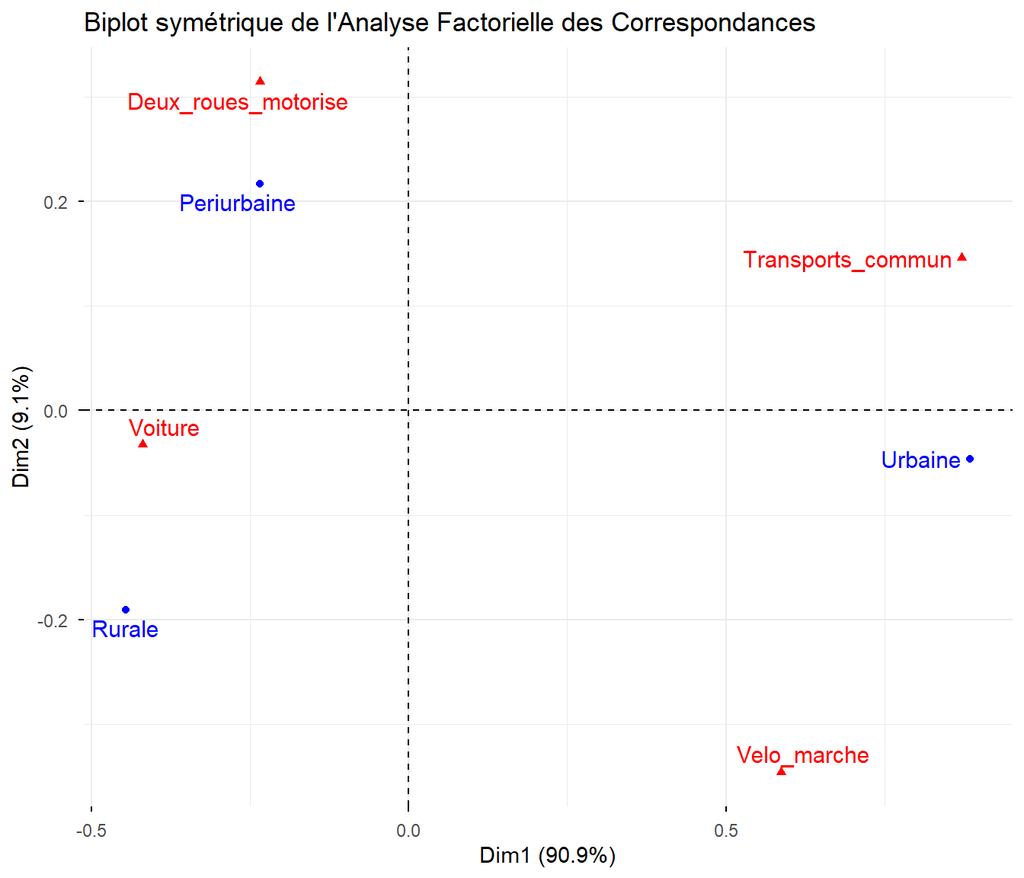

```r
fviz_ca_biplot(res.ca, axes = c(1, 2), repel = TRUE,
               title = "Biplot symétrique de l'Analyse Factorielle des Correspondances")
```

L’Axe 1 (horizontal) est exceptionnellement fort, car il résume à lui seul 90,9 % de l’information (l’inertie totale) du jeu de données.

```r
res.ca$row$contrib[, 1]
```

```
## Periurbaine      Rurale     Urbaine
##     6.62593    22.87271    70.50136
```

```r
res.ca$row$cos2[, 1]
```

```
## Periurbaine      Rurale     Urbaine
##   0.5385237   0.8448776   0.9973018
```

```r
res.ca$col$contrib[, 1]
```

```
## Deux_roues_motorise   Transports_commun         Velo_marche             Voiture
##            1.862082           51.590195           14.624094           31.923629
```

```r
res.ca$col$cos2[, 1]
```

```
## Deux_roues_motorise   Transports_commun         Velo_marche             Voiture
##           0.3569120           0.9727315           0.7423837           0.9940182
```

Du côté des communes (profils-lignes) : Le seuil de contribution moyenne théorique est de 33,3 %. La modalité “Urbaine” domine la construction de cet axe avec une contribution massive de 70,50 %.

La commune “Rurale” participe plus modestement (22,87 %), tandis que “Periurbaine” ne contribue quasiment pas (6,63 %). Leurs cosinus carrés cos^2 confirment la fiabilité de cette lecture : “Urbaine” (0,997) et “Rurale” (0,845) sont presque parfaitement projetées et lisibles sur cet axe.

Du côté des transports (profils-colonnes) : Le seuil moyen est de 25. Deux modes de transport structurent cet axe : les “Transports_commun” (51,59 %) et la “Voiture” (31,92 %). Leurs cos^2 respectifs de 0,973 et 0,994 prouvent que ces deux modalités sont parfaitement représentées sur cette première dimension. Les mobilités “Velo_marche” (14,62 %) et surtout “Deux_roues_motorise” (1,86 %) jouent un rôle marginal dans la définition de l’axe.

# 18. Associations statistiques, analyse avec la question 5 :

En lisant les proximités depuis le centre du graphique (l’origine), corroborées par les données de la question 17, l’association la plus forte et la plus structurante du jeu de données lie la commune “Urbaine” aux “Transports_commun”.

À l’opposé, la modalité “Rurale” attire très nettement le point “Voiture”.

Confrontation avec les profils-lignes (Q5) : Ces associations visuelles sont la traduction mathématique directe du tableau de contingence en pourcentages.

Il est erroné de tirer une conclusion en mesurant l’écart direct (la distance en centimètres sur l’écran) entre le point bleu “Urbaine” et le point rouge “Transports_commun”.

Mathématiquement, ces deux nuages de points n’existent pas dans le même espace dimensionnel. Le graphique de type “biplot symétrique” est une astuce mathématique superposant deux repères distincts.

Les relations entre lignes et colonnes obéissent à des règles de barycentres (équations de transition), ce qui oblige à analyser les liens non pas par la distance absolue entre les points, mais par l’angle qu’ils forment avec le centre du graphique.

## 19. Test d’indépendance et pertinence d’une AFC sur region × transport_principalTest d’indépendance préalable

```r
tab_region_transport <- table(donneesSansNA$region, donneesSansNA$transport_principal)
chisq.test(tab_region_transport)$expected  # effectifs théoriques
```

```
##
##          Deux_roues_motorise Transports_commun Velo_marche  Voiture
##   Centre            2.916667          5.833333    3.645833 15.60417
##   Est               3.958333          7.916667    4.947917 21.17708
##   Nord              3.229167          6.458333    4.036458 17.27604
##   Ouest             4.895833          9.791667    6.119792 26.19271
##   Sud               5.000000         10.000000    6.250000 26.75000
```

```r
chisq.test(tab_region_transport)
```

```
##
##  Pearson's Chi-squared test
##
## data:  tab_region_transport
## X-squared = 13.058, df = 12, p-value = 0.3648
```

Absence de structure réelle : Les deux variables étant quasi-indépendantes (comme observé lors de l’ACP), l’inertie globale est extrêmement faible. L’AFC forcerait la création d’axes qui ne représenteraient que du “bruit” ou des variations aléatoires.

Instabilité des résultats : Le calcul de l’AFC accèlère mathématiquement les modalités rares. Les régions contenant très peu de communes deviendraient des points aberrants qui déformeraient les axes factoriels.

## 20. Synthèse et conclusion

Note de synthèse :

Nous avons analysé un jeu de données de plus de 190 communes, contenant différentes notions socio-économiques et géographiques.

De façon exhaustive, notre jeu de données contenait des informations sur la région, le type de commune, le transport principal, la densité, le revenu médian, le taux de chômage, la part de diplômés sup, le prix du m², la part de plus de 65 ans, le temps de trajet, le nombre d’équipements.

Grâce à différentes techniques et méthodes statistiques et mathématiques d’analyse de données, nous avons pu identifier différentes tendances et dépendances de certaines variables testées.

Nous avons tout d’abord pu identifier trois grands profils de communes : les communes rurales, les communes périurbaines, les communes urbaines.

Nous avons pu établir deux constats principaux après l’intégralité de cette analyse. Le premier constat que nous avons pu identifier est l’association de certains types de moyens de transport en fonction du type de commune. En effet, la voiture est privilégiée par plus de 75 % des habitants des communes rurales contre à peine 19 % des habitants des zones urbaines.

Revenons donc sur le premier constat, selon nos chiffres en % : Deux_roues_motorise Transports_commun Velo_marche Voiture Periurbaine 15.49 16.90 4.23 63.38 Rurale 8.82 2.94 11.76 76.47 Urbaine 5.66 49.06 26.42 18.87

On observe une préférence de la part des habitants en zone périurbaine pour la voiture (63 %), c’est également le cas des habitants de zones rurales (76 %). À l’inverse, les habitants urbains privilégient les transports en commun à presque 50 %.

On observe également, et c’est intéressant de le noter, que la marche est plus de trois fois plus privilégiée par les ruraux que les transports en commun, preuve d’une difficulté majeure d’accès à ceux-ci ou d’habitants ayant conscience de la difficulté de quitter leurs territoires et qui choisissent d’ajuster leur mode de vie en se déplaçant moins loin.

Nos recommandations : Dans un premier temps, il est nécessaire de développer les transports en commun en zones périurbaines, dans lesquelles ceux-ci font déjà leurs preuves et satisfont une bonne part des habitants, et dans lesquelles il est possible de faire ses trajets du quotidien en transports.

Ensuite, il peut être nécessaire d’augmenter l’offre de transports en commun en zones rurales, mais il faut avoir conscience que pour beaucoup d’habitants la voiture ou la moto sont des nécessités difficilement remplaçables pour un usage quotidien. Car une part importante d’habitants doit se déplacer depuis ces territoires enclavés pour travailler (constat 2) et qu’il est peut-être difficile pour ces habitants d’échapper à l’usage de la voiture (le temps de trajet apparaît proportionnellement inverse à la densité dans le cercle de corrélations). Il est donc également préférables de dévelloper des solutions de covoiturages, voitures à faibles consomations d’essence ou éventuellement des bornes de recharges éléctriques

## Question Bonus: Exécution de la classification (HCPC)

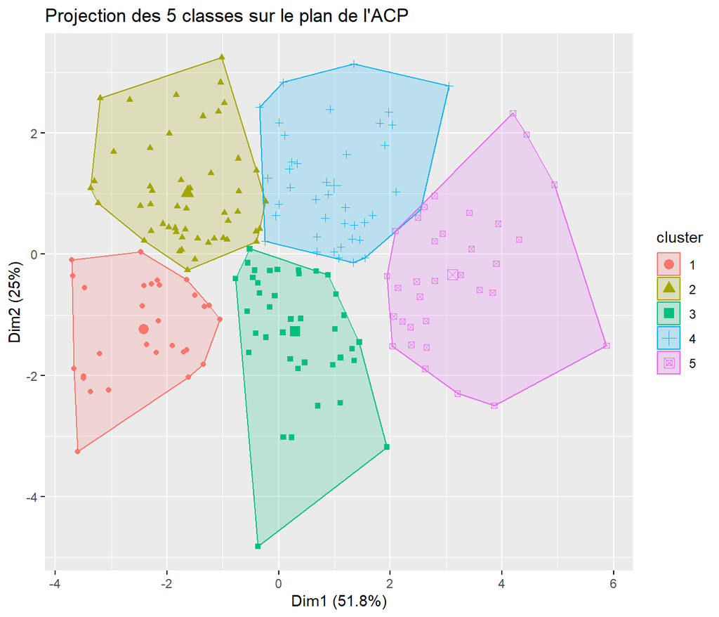

```r
res.hcpc <- HCPC(res.pca, nb.clust = -1, graph = FALSE)


fviz_cluster(res.hcpc, geom = "point", show.clust.cent = TRUE,
             main = "Projection des 5 classes sur le plan de l'ACP")
```

L’algorithme, paramétré avec nb.clust = -1, a calculé automatiquement le saut d’inertie maximal sur le dendrogramme. L’optimisation du critère de Ward a identifié qu’une partition en 5 classes était la structure mathématique modélisant le mieux les données, maximisant ainsi la variance inter-classes tout en conservant une forte homogénéité intra-classe.

Description géométrique et statistique des classes :

```
Classe 1 (Rouge - quadrant inférieur gauche) : Regroupe les communes aux coordonnées fortement négatives sur l'Axe 1 et négatives sur l'Axe 2. Elle caractérise un pôle rural profond, fortement enclavé, associé à une mobilité exclusivement automobile.

Classe 2 (Marron - quadrant supérieur gauche) : Communes également rurales (Dim 1 négative) mais moins touché par l'enclavement économique.

Classe 3 (Vert - centre inférieur) : Pôle de transition périurbaine (coordonnées proches de zéro sur la Dim 1), présentant toutefois une vulnérabilité socio-économique (Dim 2 négative).

Classe 4 (Bleu - centre supérieur) : Second pôle de transition périurbaine, mais favorisé économiquement et mieux intégré (Dim 2 positive).

Classe 5 (Violet - pôle droit) :) Elle caractérise le pôle urbain dense et riche, structurellement associé à l'usage des transports en commun et des mobilités douces.
```